# Choose time slots for a talk

Tomás E. Tecce

## The problem

I need to give an introductory talk to a class of students who will be taking an online course. I have already selected a number of possible time slots for the talks, based on my own availability. The students are located in different countries and time zones, and I’m willing to repeat my talk at least once in order to accomodate this.

I’ve asked the students to complete a poll, indicating which of the time slots they prefer; they can choose more than one option. What I would like to do is to use that information to choose two time slots in order to maximize the number of students who can attend the talk.

## The data

The poll data was collected using [Doodle](http://doodle.com). People were asked to choose among 30 possible time slots, and multiple choices were allowed. The results are collected in a CSV file which contains one row per person, and the columns correspond to the different possible time slots (labeled from S01 to S30).

```r
# Read the data file
df <- read.csv("data.csv", na.strings="", stringsAsFactors=FALSE)
# Convert the data from "OK" and NA to 0 and 1, then find the total number
# of people who chose each of the different time slots
df[is.na(df)] <- 0
df[df == "OK"] <- 1
df[,2:31] <- apply(df[,2:31], 2, as.numeric)
ts_sums <- colSums(df)
```

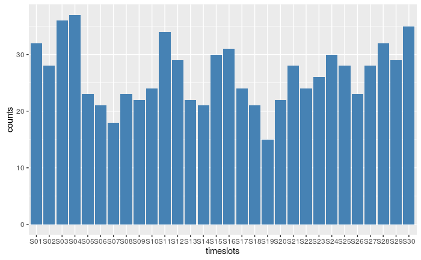

```r
library(ggplot2)
fig <- ggplot(data=data.frame(timeslots=colnames(df)[2:31],
                              counts=ts_sums[2:31]),
              aes(x=timeslots, y=counts)) + geom_bar(stat="identity", fill="steel blue")
print(fig)
```

## The method

To find two timeslots that maximize the number of distinct students that attend the introduction, I use the following method.

First, I build new columns, one for each possible permutation of time slots (slot #1 and slot #2, slot #1 and slot #3, etc). Each row contains 1 if the student can attend either of the slots, and 0 otherwise.

```r
library(dplyr)
new_names <- sapply(combn(names(df[,2:31]), 2, simplify = FALSE),
                    function(x) { paste(x, collapse="") })
for (i in 1:length(new_names)) {
  df <- mutate(df, newcol=as.numeric(df[substr(new_names[i], 1, 3)] |
                                       df[substr(new_names[i], 4, 6)]))
  colnames(df)[colnames(df)=="newcol"] <- new_names[i]
}
```

Then we sum the columns to find which time slot combination has the most attendee count.

```r
ts_sums <- colSums(df[,32:dim(df)[2]])
ts_sums[order(-ts_sums)][1:10]
```

```
S03S30 S01S30 S04S30 S02S30 S11S30 S25S30 S01S03 S01S17 S02S04 S04S17
    63     62     61     57     57     57     55     55     55     55
```

Thus, we find that by choosing slots #3 and #30 we could potentially have 63 students attending (54 per cent of the total).

We can repeat the exercise for 3 time slots:

```r
new_names <- sapply(combn(names(df[,2:31]), 3, simplify = FALSE),
                    function(x) { paste(x, collapse="") })
enddim <- dim(df)[2]
for (i in 1:length(new_names)) {
  df <- mutate(df, newcol=as.numeric(df[substr(new_names[i], 1, 3)] |
                                       df[substr(new_names[i], 4, 6)] |
                                       df[substr(new_names[i], 7, 9)]))
  colnames(df)[colnames(df)=="newcol"] <- new_names[i]
}
```